# Semeando Genética em 3 min

## Introdução

- Atividade com objetivo: **Utilização dos mapas mentais para facilitar o aprendizado de genética + divulgação de ciência para a sociedade**

**Mapa mental + vídeo de divulgação científica**

- Mapa mental $\to$ roteiro para o vídeo;
- Vídeo $\to$ divulgação da genética.

## Breve pesquisa sobre

[figure not shown]

## O que é um mapa mental?

- Desenvolvido por Tony Buzan em 1974, com base no conceito de *Radiant thinking*
- [TED - The Power of a Mind to Map: Tony Buzan at TEDxSquareMile](https://www.youtube.com/watch?v=nMZCghZ1hB4)

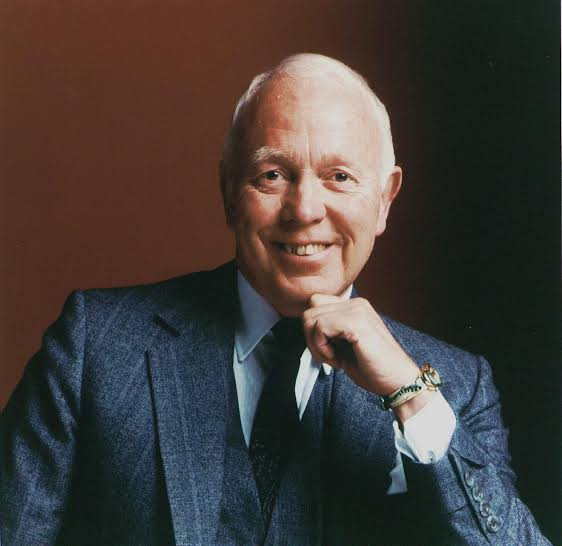

Figure 1: Criador do conceito do mapa mental - Tony Buzan

## Exemplo

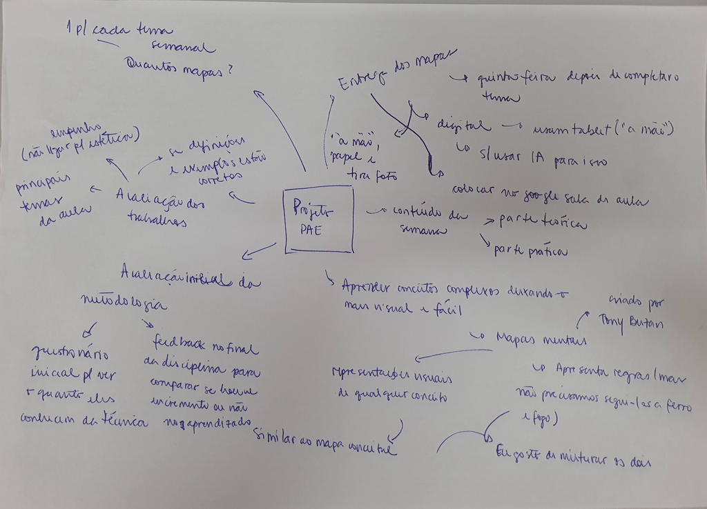

Figure 2: Exemplo de construção de mapa mental

## Amplamente utilizado

- [Estudos](https://www.youtube.com/watch?v=m1qW0wPJV1M)
- Organização de reuniões
- Planejamento de trabalhos
- Anotações durante a aula

## Fundamentos

- *“Human languange is imagination”* = representação visual de conceitos ou de processos.
- O uso de palavras-chaves é uma das maneiras mais eficazes de memorizar algo
  - [TED - *Mind mapping for education*](https://youtu.be/_bRmXUCG7W4?si=GKveSXXDYXP7Q-vK&t=537)
  - Útil para relembrar, testar a retenção de informação, ou conectar mais informações de maneira visual ao que já se sabe.

## Como fazer a atividade

**1. Mapa Mental (Roteiro)**

- Deve ser **feito à mão** obrigatoriamente.
- Apenas **1 mapa por grupo**, servindo como o roteiro do vídeo.

**2. Produção do Vídeo**

- Gravação feita com a câmera de um **celular**.
- O vídeo **não** pode ser confeccionado utilizando ferramentas de inteligência artificial.
- Use a criatividade do próprio grupo!

## Como fazer a atividade

**3. Conteúdo e Formato**

- **Duração:** Até 3 minutos (formato *Shorts*, vídeo curto gravado verticalmente).
- Explicar o conteúdo da semana descrito no mapa mental para um **público leigo** (linguagem acessível).

**4. Envio e Entrega**

- Publicar o vídeo no **YouTube**.
- Enviar o **link do vídeo** na plataforma e-Disciplinas, junto do mapa mental.
- **Prazos de entrega**: uma semana após o término de cada tema (frequência semanal ou quinzenal).

## Exemplos do que é esperado

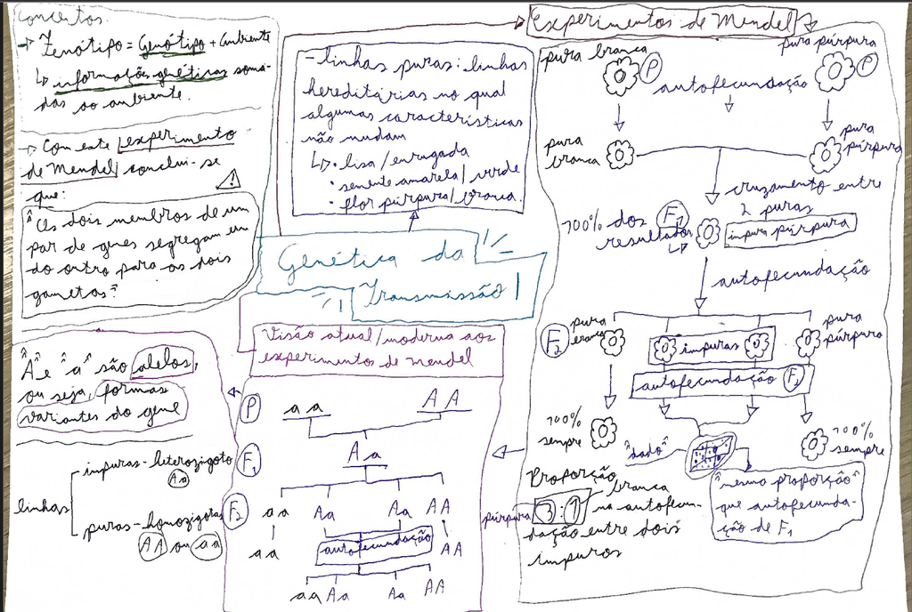

Figure 3: Boa estrutura e bom uso de cores de esquemas

## Exemplos do que é esperado

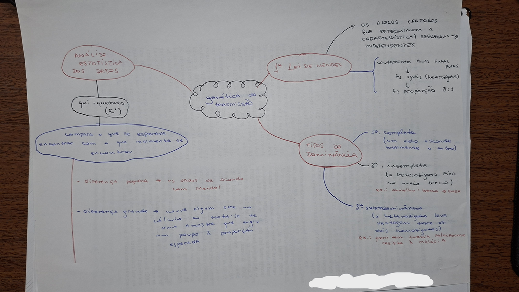

Figure 4: Estrutura objetiva, clara e bom uso de cores

## Exemplos do que é esperado

[figure not shown]

Figure 5: Com todos os conceitos e detalhes

## Materiais de apoio

- University of Maine - [Creating Mind Maps](https://usm.maine.edu/learning-commons/mind-mapping/)
- Guia do estudante [Como fazer um mapa mental](https://guiadoestudante.abril.com.br/estudo/como-fazer-um-mapa-mental/)
- TED - [Want to learn better? Star mind mapping](https://www.youtube.com/watch?v=5nTuScU70As)
- The Universitry of Adelaide - [Guia para utilização de mapas mentais](https://www.adelaide.edu.au/writingcentre/sites/default/files/docs/learningguide-mindmapping.pdf)
- The Mind Map Book